# Figuras de la tesis: sesgo de supervivencia del enlace RSH/CONADI (Anexo)

Figuras 2, 3, S2 y S6 del documento vigente, embebidas para publicación

Fecha de publicación

11 de octubre de 2026

Documento compañero de publicación: embebe las figuras del análisis de sesgo de supervivencia del enlace a registros sociales, tal como están insertadas en el documento de tesis vigente, con sus pies exactos. No ejecuta análisis; solo empaqueta las imágenes en un HTML autocontenido.

## Figura 2

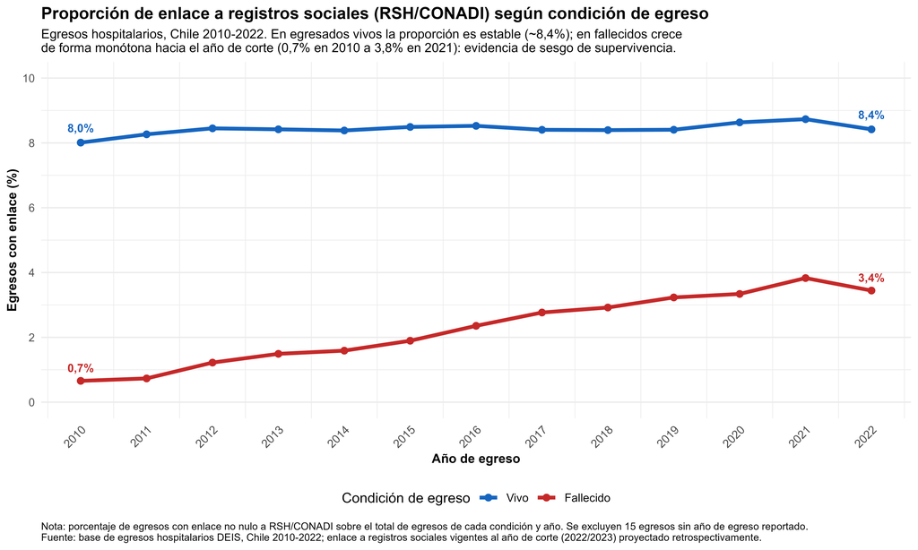

**Figura 2.** Proporción de egresos hospitalarios con enlace a registros sociales (Registro Social de Hogares o CONADI), según año y condición de egreso. Chile, 2010-2022. Nota: en los egresados vivos la proporción con enlace se mantuvo estable entre 8,0% y 8,7%; en los fallecidos varió entre 0,7% (2010) y 3,8% (2021). Fuente: Departamento de Estadísticas e Información de Salud (DEIS), Ministerio de Salud; Registro Social de Hogares, Ministerio de Desarrollo Social y Familia; Corporación Nacional de Desarrollo Indígena (CONADI).

## Figura 3

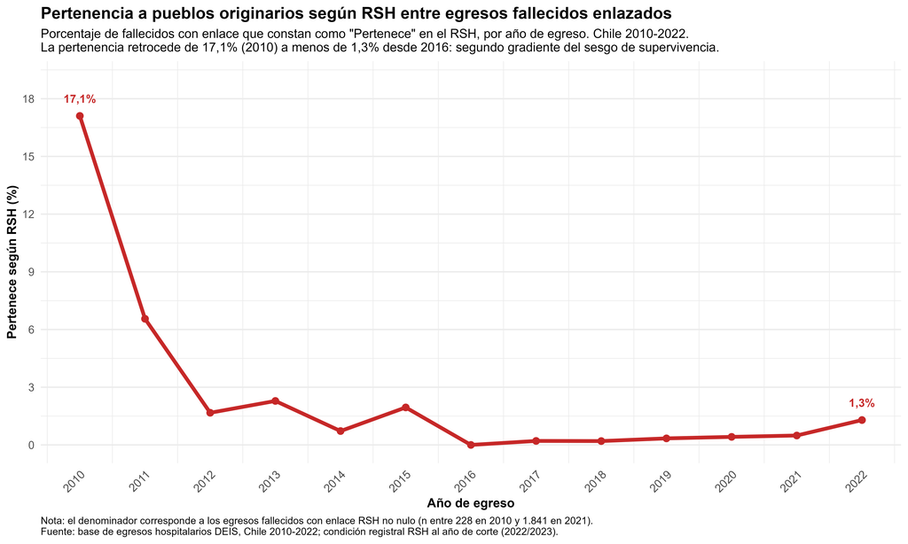

**Figura 3.** Proporción de egresos fallecidos con enlace identificados como pertenecientes a pueblos indígenas según el Registro Social de Hogares, por año de egreso. Chile, 2010-2022. Nota: la proporción descendió de 17,1% en 2010 a valores entre 0,0% y 1,3% en 2016-2022. Fuente: Departamento de Estadísticas e Información de Salud (DEIS), Ministerio de Salud; Registro Social de Hogares, Ministerio de Desarrollo Social y Familia.

## Figura S2

[figure not shown]

**Figura S2.** Distribución del enlace a registros sociales (RSH/CONADI) según sexo, grupo etario y región del establecimiento. Chile, 2010-2022.

## Figura S6

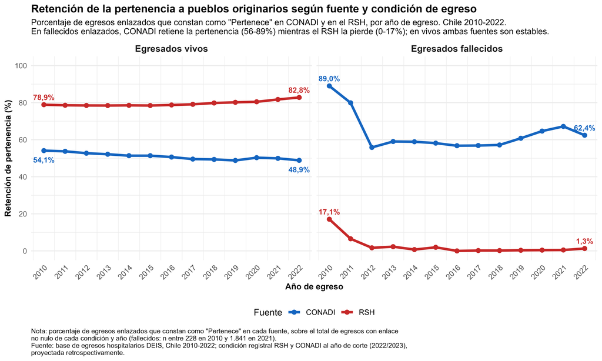

**Figura S6.** Porcentaje de egresos enlazados a registros sociales que constan como pertenecientes a pueblos indígenas en CONADI y en el Registro Social de Hogares, por año de egreso y condición de egreso. Chile, 2010-2022. Nota: en los egresados vivos ambas fuentes se mantienen estables; en los fallecidos, CONADI retiene la pertenencia (55,8-89,0% según el año) y el RSH la pierde (0,0-17,1%). Fuente: Departamento de Estadísticas e Información de Salud (DEIS), Ministerio de Salud; Registro Social de Hogares, Ministerio de Desarrollo Social y Familia; Corporación Nacional de Desarrollo Indígena (CONADI).